# ANLY 545_50 HW_5

Mahesh

January 20, 2019

## Exercise 6.2

**The data set criminal in the package logmult gives the 4 × 5 table below of the number of men aged 15-19 charged with a criminal case for whom charges were dropped in Denmark from 1955-1958. Carry out a simple correspondence analysis on this table.**

**a. What percentages of the Pearson X2 (Chi-square) for association are explained by the various dimensions?**

```r
library(ca);library(MASS);library(factoextra)
data("criminal", package = "logmult")
summary(ca(criminal))
```

```
##
## Principal inertias (eigenvalues):
##
##  dim    value      %   cum%   scree plot
##  1      0.004939  90.3  90.3  ***********************
##  2      0.000491   9.0  99.3  **
##  3      3.8e-050   0.7 100.0
##         -------- -----
##  Total: 0.005468 100.0
##
##
## Rows:
##     name   mass  qlt  inr    k=1 cor ctr    k=2 cor ctr
## 1 | 1955 |  230  996  347 |   88 939 361 |  -22  58 223 |
## 2 | 1956 |  230  978  157 |   58 908 157 |   16  71 124 |
## 3 | 1957 |  269  984  111 |  -39 669  82 |   27 315 391 |
## 4 | 1958 |  271  999  385 |  -85 938 399 |  -22  61 262 |
##
## Columns:
##     name   mass  qlt  inr    k=1 cor ctr    k=2 cor ctr
## 1 |   15 |   99  998  185 | -101 992 203 |   -7   5  11 |
## 2 |   16 |  197  996  312 |  -91 959 331 |  -18  37 128 |
## 3 |   17 |  211  991   75 |  -23 281  23 |   37 710 594 |
## 4 |   18 |  254  989  235 |   70 980 255 |    7   9  24 |
## 5 |   19 |  239  990  194 |   62 877 188 |  -22 112 243 |
```

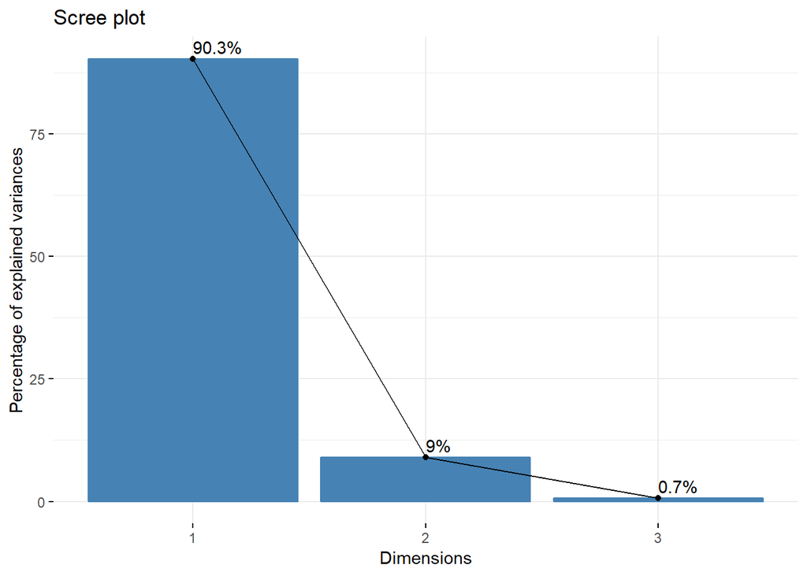

```r
fviz_screeplot(ca(criminal), addlabels = TRUE)
```

From the summary and the plot, we see that the proportion of pearson X2 (Chi-square) associated with Dimension 1 is 90.3% and that with Dimension 2 is 9%. Dimension 1 and 2 explains more than 99% of the variation and can also be used to achieve dimensionality reduction. Remaining 0.7% is associated with Dimension 3.

**b. Plot the 2D correspondence analysis solution. Describe the pattern of association between year and age.**

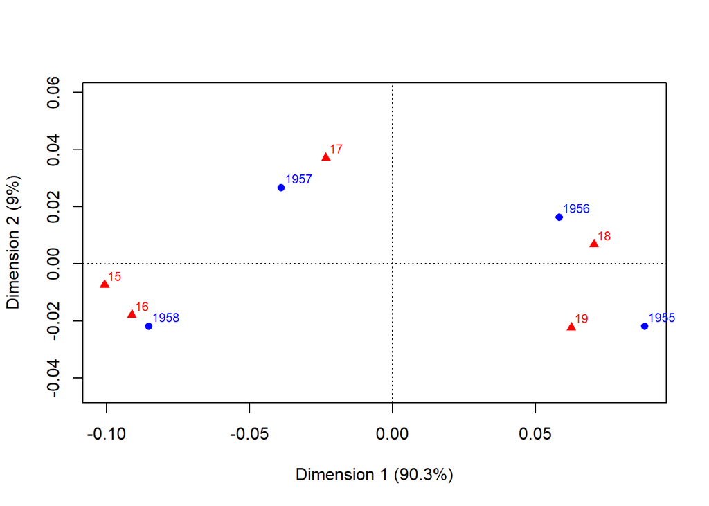

```r
plot(ca(criminal))
```

Points closer to each other indicates strong association (given the data is large and independent). From the plot, we can confirm that Age 18 and year 1956 are closely associated. Similarly, age 15 and 16 are closely associated with the year 1958.

## Exercise 6.11

**The data set Vietnam in vcdExtra gives a 2 × 5 × 4 contingency table in frequency form reflecting a survey of student opinion on the Vietnam War at the University of North Carolina in May 1967. The table variables are sex, year in school, and response, which has categories: (A) Defeat North Vietnam by widespread bombing and land invasion; (B) Maintain the present policy; (C) De-escalate military activity, stop bombing and begin negotiations; (D) Withdraw military forces immediately.**

**a. Using the stacking approach, carry out a correspondence analysis corresponding to the loglinear model [R][YS], which asserts that the response is independent of the combinations of year an sex.**

```r
data("Vietnam",package="vcdExtra")
Vietnam = within(Vietnam,{year_sex = paste(year, sex)})
Vietnam.tab = xtabs(Freq ~ year_sex + response, data = Vietnam)
Vietnam.ca <- ca(Vietnam.tab)
summary(Vietnam.ca)
```

```
##
## Principal inertias (eigenvalues):
##
##  dim    value      %   cum%   scree plot
##  1      0.085680  73.6  73.6  ******************
##  2      0.027881  23.9  97.5  ******
##  3      0.002854   2.5 100.0  *
##         -------- -----
##  Total: 0.116415 100.0
##
##
## Rows:
##      name   mass  qlt  inr    k=1 cor ctr    k=2 cor ctr
## 1  | 1Fml |   24  818   13 | -167 452   8 | -150 367  20 |
## 2  | 1Mal |  139  997  181 |  386 986 242 |  -41  11   8 |
## 3  | 2Fml |   16  995   35 | -407 647  31 | -299 349  51 |
## 4  | 2Mal |  140  984  131 |  326 982 175 |  -15   2   1 |
## 5  | 3Fml |   53  999  112 | -334 453  69 | -367 547 256 |
## 6  | 3Mal |  138  904   40 |  175 904  49 |   -4   0   0 |
## 7  | 4Fml |   32  982   37 | -344 887  44 | -113  95  15 |
## 8  | 4Mal |  149  383   23 |   81 372  11 |   14  11   1 |
## 9  | 5Fml |   59  994  153 | -453 686 143 | -304 309 197 |
## 10 | 5Mal |  248 1000  276 | -281 608 228 |  225 391 451 |
##
## Columns:
##     name   mass  qlt  inr    k=1 cor ctr    k=2 cor ctr
## 1 |    A |  255  985  381 |  414 985 509 |   -1   0   0 |
## 2 |    B |  235  720   60 |  135 608  50 |   58 112  28 |
## 3 |    C |  419  999  283 | -247 773 298 | -133 226 267 |
## 4 |    D |   92  995  276 | -366 383 143 |  463 612 705 |
```

**b. Construct an informative 2D plot of the solution, and interpret in terms of how the response varies with year for males and females.**

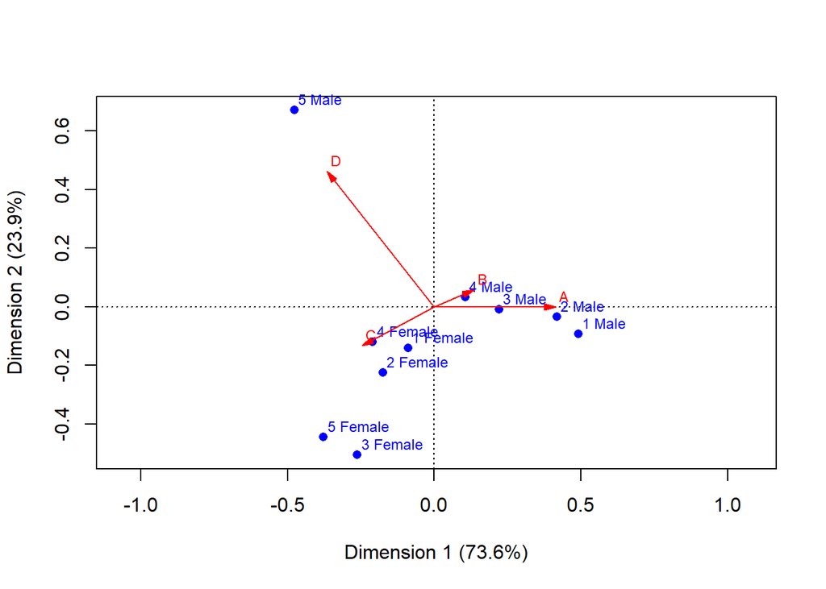

```r
plot(Vietnam.ca, map = "colgreen", arrows = c(FALSE,TRUE))
```

**c. Use mjca () to carry out an MCA on the three-way table. Make a useful plot of the solution and interpret in terms of the relationship of the response to year and sex.**

```r
summary(mjca(Vietnam.tab))
```

```
##
## Principal inertias (eigenvalues):
##
##  dim    value      %   cum%   scree plot
##  1      0.085680  73.6  73.6  ******************
##  2      0.027881  23.9  97.5  ******
##  3      0.002854   2.5 100.0  *
##  4      00000000   0.0 100.0
##  5      00000000   0.0 100.0
##  6      00000000   0.0 100.0
##  7      00000000   0.0 100.0
##         -------- -----
##  Total: 0.116415
##
##
## Columns:
##                   name   mass  qlt  inr    k=1 cor ctr    k=2 cor ctr
## 1  | year_sex:1 Female |   12  818   80 |  167 452   4 | -150 367  10 |
## 2  |   year_sex:1 Male |   70  997   72 | -386 986 121 |  -41  11   4 |
## 3  | year_sex:2 Female |    8  995   81 |  407 647  15 | -299 349  25 |
## 4  |   year_sex:2 Male |   70  984   72 | -326 982  87 |  -15   2   1 |
## 5  | year_sex:3 Female |   27  999   78 |  334 453  34 | -367 547 128 |
## 6  |   year_sex:3 Male |   69  904   71 | -175 904  25 |   -4   0   0 |
## 7  | year_sex:4 Female |   16  982   79 |  344 887  22 | -113  95   7 |
## 8  |   year_sex:4 Male |   75  383   70 |  -81 372   6 |   14  11   1 |
## 9  | year_sex:5 Female |   30  994   78 |  453 686  71 | -304 309  99 |
## 10 |   year_sex:5 Male |  124 1000   64 |  281 608 114 |  225 391 225 |
## 11 |        response:A |  127  985   65 | -414 985 255 |   -1   0   0 |
## 12 |        response:B |  117  720   63 | -135 608  25 |   58 112  14 |
## 13 |        response:C |  210  999   50 |  247 773 149 | -133 226 134 |
## 14 |        response:D |   46  995   77 |  366 383  72 |  463 612 352 |
```

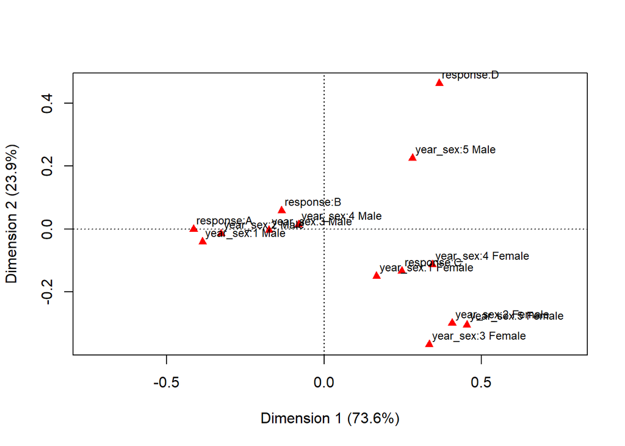

```r
plot(mjca(Vietnam.tab))
```